# COURSE PROJECT 5.1

John Como

2025-01-13

### Loading and preprocessing the data

#### Working directory set and data loaded ito R

```r
setwd("C:/Users/user/Dropbox/Education/Coursera/JH Data Science/REPRODUCIBLE RESEARCH/COURSE PROJECT 5.1/")
dataset<-read.csv("activity.csv", header= TRUE)
```

### 1. What is the mean total number of steps taken per day?

#### 1a. Calculate the total number of steps taken per day.

```r
totalStepsPerDay<-aggregate(steps~date, dataset, sum, na.action=na.omit)
print(totalStepsPerDay)
```

```
##          date steps
## 1  2012-10-02   126
## 2  2012-10-03 11352
## 3  2012-10-04 12116
## 4  2012-10-05 13294
## 5  2012-10-06 15420
## 6  2012-10-07 11015
## 7  2012-10-09 12811
## 8  2012-10-10  9900
## 9  2012-10-11 10304
## 10 2012-10-12 17382
## 11 2012-10-13 12426
## 12 2012-10-14 15098
## 13 2012-10-15 10139
## 14 2012-10-16 15084
```

[output cut: 39 more lines]

#### 1b. Make a histogram of the total number of steps taken each day.

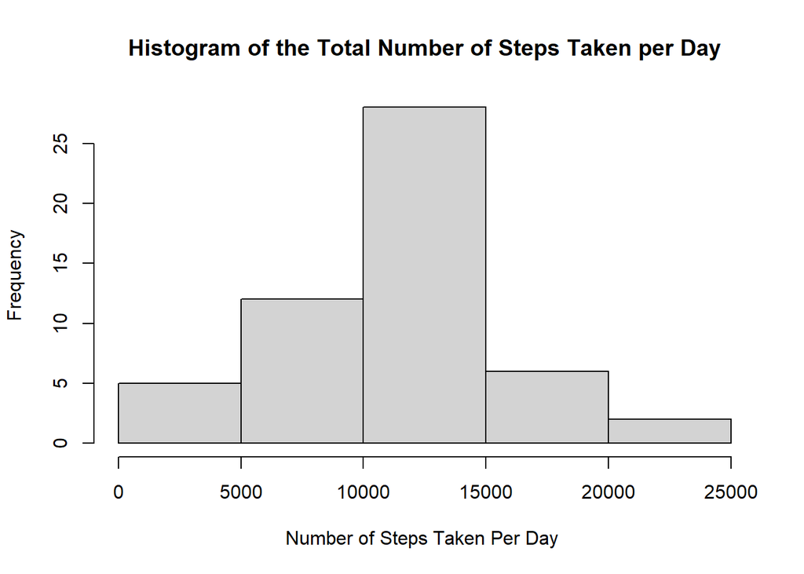

```r
hist(totalStepsPerDay$steps, breaks = c(0,5000,10000,15000,20000,25000), xaxt='n', xlab="Number of Steps Taken Per Day ",         main="Histogram of the Total Number of Steps Taken per Day")
axis(side=1, at=as.integer(c(0,5000,10000,15000,20000,25000)))
```

#### 1c. Calculate and report the mean and median of the total number of steps taken per day,

```r
library(dplyr)
totalStepsSummary <- summarise(totalStepsPerDay, meanOfTotalSteps=mean(totalStepsPerDay$steps), medianOfTotalSteps=median(totalStepsPerDay$steps))
print(totalStepsSummary)
```

```
##   meanOfTotalSteps medianOfTotalSteps
## 1         10766.19              10765
```

### 2. What is the average daily activity pattern?

#### 2a. Make a time series plot (i.e. type = “l”) of the 5-minute interval (x-axis) and the average number of steps taken, averaged across all days (y-axis)

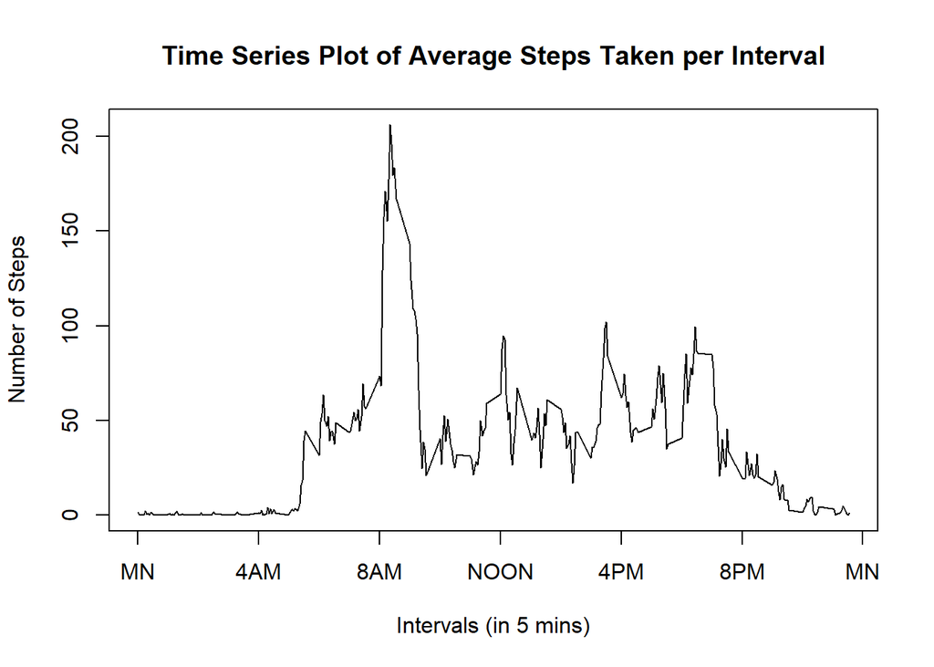

```r
stepsInterval<-aggregate(steps~interval, dataset, mean)
plot(x=stepsInterval$interval, y=stepsInterval$steps, type="l", xaxt="n", main="Time Series Plot of Average Steps Taken per Interval", ylab="Number of Steps", xlab="Intervals (in 5 mins)")
axis(side=1, labels=c("MN", "4AM", "8AM", "NOON", "4PM","8PM", "MN"), at=c(0, 400, 800, 1200,1600,2000,2400))
```

#### 2b. Which 5-minute interval, on average across all the days in the dataset, contains the maximum number of steps?

```r
maxSteps<-stepsInterval[grep(max(stepsInterval$steps), stepsInterval$steps), ]
print(maxSteps)
```

```
##     interval    steps
## 104      835 206.1698
```

### 3. Imputing missing values

#### 3a. Note that there are a number of days/intervals where there are missing values (coded as NA). The presence of missing days may introduce bias into some calculations or summaries of the data. Calculate and report the total number of missing values in the dataset (i.e. the total number of rows with NAs).

```r
data.frame(steps=sum(is.na(dataset$steps)),
           interval=sum(is.na(dataset$interval)),
           date=sum(is.na(dataset$date)))
```

```
##   steps interval date
## 1  2304        0    0
```

#### 3b. Devise a strategy for filling in all of the missing values in the dataset. The strategy does not need to be sophisticated. For example, you could use the mean/median for that day, or the mean for that 5-minute interval, etc.

```r
#### I chose to replace the NAs with the mean for each interval.
```

#### 3c. Create a new dataset that is equal to the original dataset but with the missing data filled in.

```r
datasetNoNA<-subset(dataset, steps!="NA")
rowsNA<-which(is.na(dataset[,1]))
datasetIsNA<-dataset[rowsNA,]

for (i in 1:dim(stepsInterval)[1]) {
  rows2Fill<-which(datasetIsNA[,3]==stepsInterval[i,1])
  datasetIsNA[rows2Fill,1]<-stepsInterval[i,2]
}
datasetNAGone <- rbind(datasetNoNA, datasetIsNA)
```

#### 3d. Make a histogram of the total number of steps taken each day and Calculate and report the mean and median total number of steps taken per day.

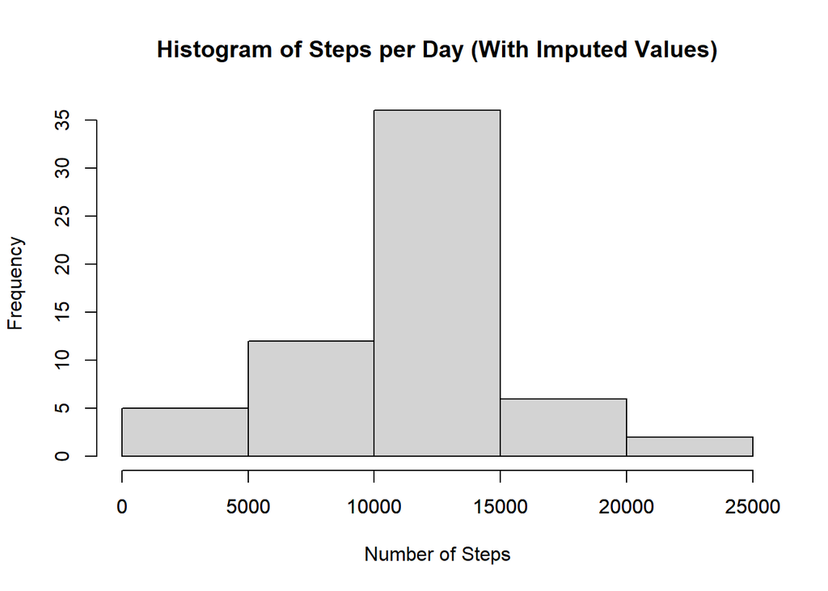

```r
total_steps_per_day<-aggregate(datasetNAGone[1], by=datasetNAGone[2], sum)
hist(total_steps_per_day[,2], breaks=c(0,5000,10000,15000,20000,25000), xlab="Number of Steps", main="Histogram of Steps per Day (With Imputed Values)")
axis(side=1, at=as.integer(c(0,5000,10000,15000,20000,25000)))
```

```r
imputedStepsSummary <- summarise(total_steps_per_day,
                                 meanOfTotalSteps=mean(total_steps_per_day$steps),
                                 medianOfTotalSteps=median(total_steps_per_day$steps))
imputedStepsSummary
```

```
##   meanOfTotalSteps medianOfTotalSteps
## 1         10766.19           10766.19
```

### 4. Are there differences in activity patterns between weekdays and weekends? For this part the weekdays() function may be of some help here. Use the dataset with the filled-in missing values for this part.

#### 4a. Create a new factor variable in the dataset with two levels – “weekday” and “weekend” indicating whether a given date is a weekday or weekend day.

```r
datasetNAGone[,4]<-(weekdays(as.POSIXct(datasetNAGone[,2])))
colnames(datasetNAGone)<-c(colnames(datasetNAGone)[1:3], "day")
datasetWD<-subset(datasetNAGone, (day!="Saturday") & (day!="Sunday"))
datasetWE<-subset(datasetNAGone, (day=="Saturday") | (day=="Sunday"))
```

#### 4b. Make a panel plot containing a time series plot (i.e. type = “l”) of the 5-minute interval (x-axis) and the average number of steps taken, averaged across all weekday days or weekend days (y-axis). See the README file in the GitHub repository to see an example of what this plot should look like using simulated data.

#### For WEEKDAYS

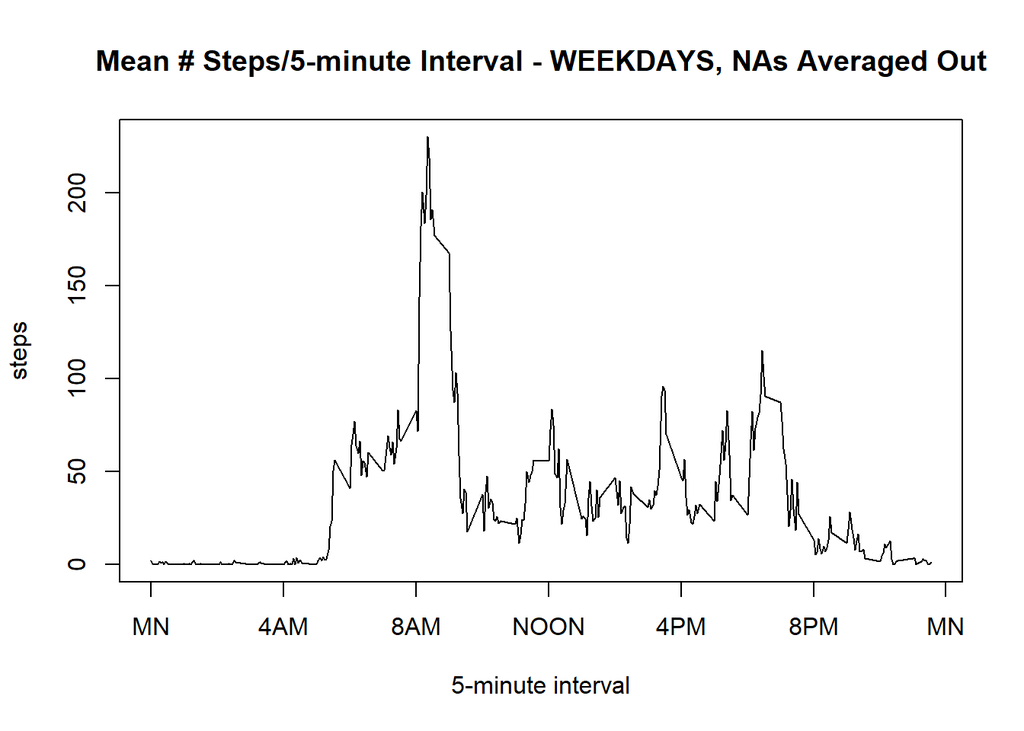

```r
mean_steps_per_interval_WD<-aggregate(datasetWD[1], by = datasetWD[3], mean, na.rm=TRUE)
plot(mean_steps_per_interval_WD, type='l',xaxt='n', main="Mean # Steps/5-minute Interval - WEEKDAYS, NAs Averaged Out", xlab="5-minute interval")
axis(side=1, at=c(0, 400, 800, 1200,1600,2000,2400), labels=c("MN", "4AM", "8AM", "NOON", "4PM","8PM", "MN"))
```

#### And the same calculation for WEEKENDS:

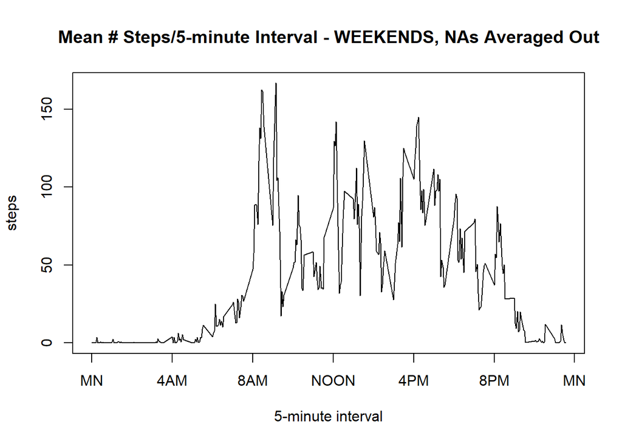

```r
mean_steps_per_interval_WE<-aggregate(datasetWE[1], by = datasetWE[3], mean, na.rm=TRUE)
plot(mean_steps_per_interval_WE, type='l',xaxt='n', main="Mean # Steps/5-minute Interval - WEEKENDS, NAs Averaged Out", xlab="5-minute interval")
axis(side=1, at=c(0, 400, 800, 1200,1600,2000,2400), labels=c("MN", "4AM", "8AM", "NOON", "4PM","8PM", "MN"))
```

#### It seems that on the WEEKDAYS, there is a spike of activity at about 8AM. The data for WEEKENDS is not as prominent and people seem to have more activity later in the day. This makes sense, considering that most people work during the daytime on WEEKDAYS and thus have limited opportunities to be active at these times.